# Лабораторная работа №8

Операционные системы

Соколова Александра Олеговна.

Российский университет дружбы народов, Москва, Россия

30 марта 2024

## Докладчик

- Соколова Александра Олеговна
- Студентка группы НКАбд-05-23
- Факультет физико-математических и естественных наук
- Российский университет дружбы народов
- [1132236034]
- https:///ssokolova21.github.io

## Цель работы

Цель данной лабораторной работы - ознакомление с инструментами поиска файлов и фильтрации текстовых данных, а также приобретение практических навыков по управлению процессами (и заданиями), по проверке использования диска и по обслуживанию файловых систем.

# Выполнение лабораторной работы

## Выполнение лабораторной работы

Записала в файл file.txt названия файлов из каталога /etc с помощью перенаправления “>”.

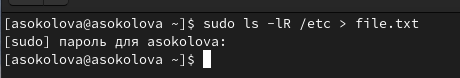

Запись в файл

## Выполнение лабораторной работы

Добавила в созданный файл имена файлов из домашнего каталога, используя перенаправление “>>” в режиме добавления.

## Выполнение лабораторной работы

Вывела на экран имена всех файлов, имеющих расширение “.conf” с помощью утилиты grep

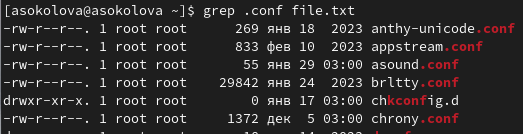

Поиск файлов определенного расширения

## Выполнение лабораторной работы

Добавила вывод прошлой команды в новый файл conf.txt с помощью перенаправления “>”.

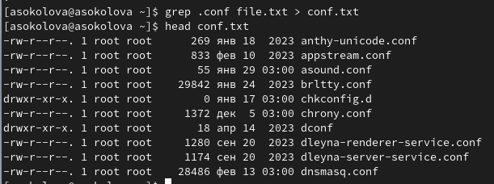

Запись в файл

## Выполнение лабораторной работы

Определяю, какие файлы в домашнем каталоге начинаютя с символа “c” с помощью утилиты find, прописываю ей в аргументах домашнюю директорию, выбираю опцию -name.

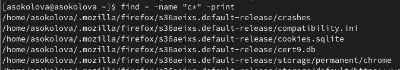

Поиск файлов, начинающихся с определенного элемента

## Выполнение лабораторной работы

Второй способ использовать утилиту ls -lR и использовать grep, чтобы найти элементы с первым символом c.

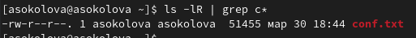

Поиск файлов, начинающихся с определенного элемента

## Выполнение лабораторной работы

Запускаю в фоновом режиме (на это указывает символ &) процесс, который будет записывать в файл logfile файлы, имена которых начинаются с log.

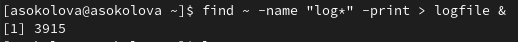

Создание фонового процесса

## Выполнение лабораторной работы

Запускаю в консоли в фоновом режиме редактор mousepad.

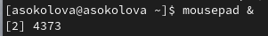

Создание фонового процесса

## Выполнение лабораторной работы

С помощью утилиты ps определяю идентификатор процесса mousepad, его значение 4373. Также мы можем определить идентификатор с помощью pgrep.

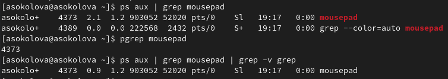

Поиск идентификатора процесса

## Выполнение лабораторной работы

Использую команду kill и идентификатор процесса, чтобы его удалить.

## Выполнение лабораторной работы

Использую утилиту df. Эта утилита нам нужна, чтобы выяснить, сколько свободного места есть у системы.

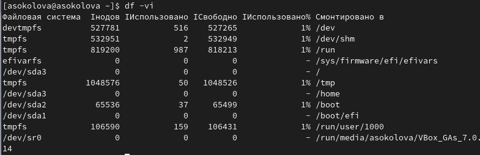

Утилита df

## Выполнение лабораторной работы

Использую утилиту du. Она нужна чтобы просмотреть, сколько места занимают файлы в определенной директории.

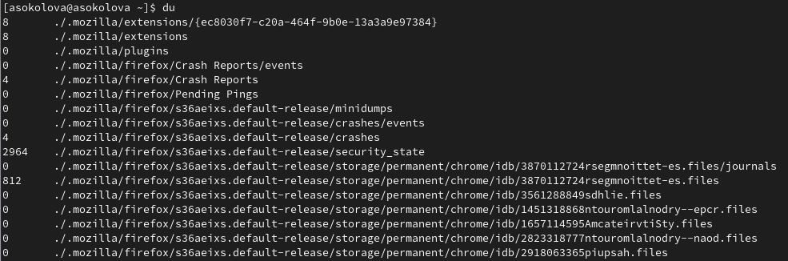

Утилита du

## Выполнение лабораторной работы

Вывела имена всех директорий, имеющихся в моем домашнем каталоге.

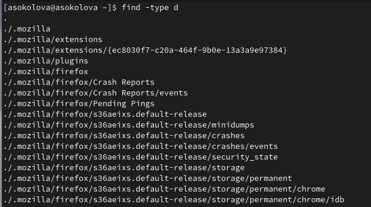

## Выводы

В результате данной лабораторной работы я ознакомилась с инструментами поиска файлов и фильтрации текстовых данных, а также приобрела практические навыки по управлению процессами (и заданиями), по проверке использования диска и по обслуживанию файловых систем.